# Tropical Cyclone Analysis

Single changepoint & Regression Methods

Author

Tom Fisher

Published

July 9, 2026

# Methods

Before performing the analysis, we discuss the different methods used.

## Regression Based methods

The regression approaches use **Generalized Linear Models** and **Likelihood Ratio testing** (McCullagh and Nelder 2019).

### For Count Data

For the data consisting of counts (number of non-shorties per season and number of major storms per season) we perform a **Poisson regression with a log-link function**. That is, we model:

$$\log(Count) = \beta_0 + \beta_1\times Year$$

which in the original units looks like

$$Count = \exp(\beta_0 + \beta_1\times Year) = \exp(\beta_0)\times \exp(\beta_1\times Year)$$

So for the Poisson based method, all the effects we find are multiplicative.

It is worth noting that the Poisson regression is arguably more reliable than standard linear regression (particularly in the six basins) since we are working with moderately small counts. Inference is done using a Likelihood Ratio test on the $\beta$ coefficient using the `drop1()` function in R. Some residual diagnostics are provided for each fitted model.

I also report values from the predictions based on these models (confidence intervals are provided for these predictions). This provides some context of what the model is suggesting. We use the prediction at the first and last time points to find an *overall trend*, that trend is then scaled to the #/decade level for easier interpretation.

### For Proportions

For the proportional data (proportion of major storms and proportion of intense storms), we are using a **Logistic Regression**. Let $p$=proportion of major (or intense) storms, we are modeling

$$\log\left(\frac{p}{1-p}\right) = \beta_0 + \beta_1\times Year$$

So again, when interpreting we need to transform back to the original units. It is worth noting that the associated hypothesis test for this regression must be interpreted in terms of log-odds. It is also worth noting that when performing this logistic regression we are implicitly assuming that the process controlling the total counts of storms, is not changing.

Again, a likelihood ratio test is used for significance of the $\beta_1$ coefficient. We provide predicted probability values at the first and last time point (with confidence intervals), and from those values find an *overall trend* (%/decade). Residual diagnostics are also provided.

## Changepoint Approaches

The regression approaches assume a fairly restrictive structure – we are assuming some underlying linear model. That is, any changes we see in the record are following some underlying linear trend. In the changepoint approach, we are simply looking for shifts in the mean of the process. **Our primary results are based on the changepoint methods.**

At some level, both methods look for changes, or non-homegenieties, in the data, but the changepoint approach doesn’t require that linearity assumption.

### At Most One Changepoint (AMOC)

We perform some iid **SCUSUM test** (Lund et al. 2023) to look for at most one changepoint. The SCUSUM statistic is defined as
$$\mbox{SCUSUM}=\frac{1}{n}\sum_{t=1}^n \mbox{CUSUM}(t)^2$$
for sample size $n$. The details of $\mbox{CUSUM}(t)$ for our two scenarios is outlined below.

The changepoint is found via
$$k = \text{argmax} \left|\text{CUSUM}(k)\right|.$$
Under the null hypothesis of no changes, $\text{SCUSUM}$ converges to $\int_0^1 B^2(t)dt$, where $\{ B(t) \}_{t=0}^{t=1}$ is the classic Brownian bridge process of empirical statistics. We used the distribution approximations in (Tolmatz 2002) to compute $p$-values. This provides the most likely changepoint location (given only a single changepoint can occur) and its corresponding $p$-value.

It is worth noting that CUSUM based tests can be conservative in practice (reported $p$-values may be slightly elevated) – we see this a little bit in the simulation study report. A boostrapping/simulation type approach could be performed but here we use the asymptotic approach partially because it is conservative.

### Changepoint for Frequencies

For the cyclone count series, we are assuming each observation, $X_t$, is a Poisson random variable where the mean of the series is determine by a rate parameter. Statistically speaking, when looking for changes in the series we are looking for a change in the rate, or mean, parameter $\lambda_t$. The $\text{CUSUM}(k)$ statistic can be calculated via
$$\mbox{CUSUM}(k)= \frac{1}{\hat{\sigma} \sqrt{n}}\left[ \sum_{t=1}^k X_t - \frac{k}{n} \sum_{t=1}^{n} X_t \right]$$
and the variance estimate is found via $\hat{\sigma}^2 = n^{-1} \sum_{t=1}^n X_t$ under the assumption of Poisson data (Robbins et al. 2011).

### Changepoint for Proportions

When working with the proportion of major (or intense) storms, we perform a CUSUM comparison on $\hat{p}_t$, the observed proportion of major (or intense) storms at time $t$. Let $Y_t$ be the number of major (or intense) storms in year $t$ and $X_t$ is the total number of storms in that year. Based on the Poisson-Binomial likelihood arguments we calculate
$$\hat{p}_t = Y_t/X_t.$$
The $\mbox{CUSUM}(k)$ statistic is calculated on the $\hat{p}_t$ terms as
$$\mbox{CUSUM}(k)= \frac{1}{\hat{\sigma} \sqrt{n}}\left[ \sum_{t=1}^k \hat{p}_t - \frac{k}{n} \sum_{t=1}^{n} \hat{p}_t \right].$$
The standard deviation estimation in this case is unwieldy but can be found through conditional expectation arguments:
$$\mbox{Var}(\hat{p}_t) = E\left[\mbox{Var}(\hat{p}_t | X_t)\right] + \mbox{Var}\left( E[\hat{p}_t|X_t]\right).$$
Detailed derivation reveals
$$\mbox{Var}(\hat{p}_t) = p^2e^{-\lambda}(1-e^{-\lambda}) + p(1-p)\sum_{k=1}^\infty \frac{e^{-\lambda}\lambda^k}{k(k!)}.$$
We estimate this variance by using
$$\hat{p} = \frac{\sum_{t=1}^n Y_t}{\sum_{t=1}^n X_t}~~~~~\mbox{and}~~~~~\hat{\lambda}=\bar{X} = \frac{1}{n}\sum_{t=1}^n X_t$$
in place of $p$ and $\lambda$ respectively. In practice, the term $e^{-\lambda}$ is small for large values of lambda, so the $p^2e^{-\lambda}(1-e^{-\lambda})$ terms goes to zero. The infinite summation is $E\left[\frac{1}{X}1_{X>0}\right]$ and is approximately equal to $1/\lambda$ for large values of $\lambda$. More importantly for our application, the sequence in the summation converges to zero fairly quickly, so the series can be well-approximated by replacing $\infty$ with a finite number.

### Modeling with Changepoints

Ultimately, a single changepoint model can be considered a special case of a generalized linear model. For example, suppose the method found a changepoint at time $c$ for tropical cyclone counts, we can build a model using a generalized linear regression with
$$\log(Count) = \beta_0 + \beta_1\times I(t>c)$$
where $I(t>c)$ is an indicator function determining if the time point $t$ is greater than the changepoint location. In this parameterization, $\beta_1$ essentially determines the shift in the Poisson rate. After determining the changepoint time, we fit this model to easily extract predictions for the mean in each regime and to build rudimentary confidence intervals around those estimates. This also allows us to perform some model assessment through GLM diagnostics.

In a similar way, we do the same modeling with logistic regression for the proportion of major and intense storms. It is important to note these models are built after determining the changepoint location using the appropriate CUSUM statistic. Additional hypothesis testing should not be performed using these models. We use these fitted models for some follow-up procedures and are not the primary testing mechanism.

# Global Cyclone Record

We begin with a study of the record across the entire globe – the Global “basin”. Our analysis looks at all non-shorties (storms that lasted at least 72 hours) and achieved tropical storm strength. We also look at those storms that achieved major hurricane strength.

## IBTrACS Quick Results

### Summary Statistics and Data

| Total Storms (Avg) | Total Storms (stddev) | Hurricanes (Avg) | Hurricanes (stddev) | Major Storms (Avg) | Major Storms (stddev) | Prop Major Storms | Intense Storms (Avg) | Intense Storms (stddev) | Prop Intense Storms |
| --- | --- | --- | --- | --- | --- | --- | --- | --- | --- |
| 54.34783 | 8.176436 | 43.28261 | 6.479585 | 23.45652 | 4.983112 | 0.4316 | 16.30435 | 5.378432 | 0.3 |

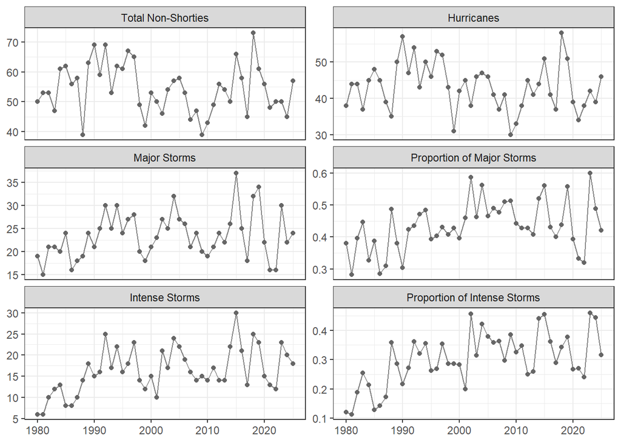

### Testing Results

**Changepoint Methods**

Here, we report the estimate mean for each segment or regime regardless of whether the test found a significant shift.

| Response | Chpt.Location | p.value | Regime1 | Regime2 | Change | Perc_Change |
| --- | --- | --- | --- | --- | --- | --- |
| Cyclone Freq | 1999 | 0.12877 | 58.16667 | 51.89286 | -6.27381 | -10.78592 |
| Hurricanes | 1999 | 0.21617 | 45.94444 | 41.57143 | -4.37302 | -9.51805 |
| Major Freq | 1992 | 0.08377 | 19.81818 | 24.60000 | 4.78182 | 24.12844 |
| Prop Major | 2002 | 0.00098 | 39.12678 | 46.82964 | 7.70286 | 19.68691 |
| Intense Freq | 1990 | 0.00003 | 9.66667 | 17.91892 | 8.25225 | 85.36813 |
| Prop Freq | 2003 | 0.00000 | 24.81869 | 35.10723 | 10.28853 | 41.45477 |

**Generalized Linear Model Approaches**

Note:

- we report the Likelihood Ratio Test for the generalized linear models, this is better to use than the default $Z$-test provided in the `summary()` output.
- the Change per decade is found by comparing the predicted value at the start time (1980) and end time (2025) and scaling by the number of years $\times 10$.

| Response | Coefficent | p.value | Start | End | Change per Decade |
| --- | --- | --- | --- | --- | --- |
| Cyclone Freq | -0.00177 | 0.23875 | 56.54650 | 52.20565 | -0.94366 |
| Hurricanes | -0.00177 | 0.29487 | 45.02713 | 41.58275 | -0.74878 |
| Major Freq | 0.00395 | 0.08521 | 21.43301 | 25.60065 | 0.90601 |
| Prop Major | 0.01009 | 0.00093 | 37.74476 | 48.84082 | 2.41219 |
| Intense Freq | 0.01157 | 0.00003 | 12.42092 | 20.90422 | 1.84420 |
| Prop Freq | 0.01913 | 0.00000 | 21.67912 | 39.56116 | 3.88740 |

## IBTrACS Full Analysis

### Changepoint Methods

#### Change in Non-Shorty Counts

```
  SCUSUM Stat chpt Location       p-value
    0.3225263    18.0000000     0.1287651
```

In regime one, the mean number of storms is 58.1666667 (CI: 54.7478963, 61.7989245) and in regime two, the mean number of storms is 51.8928571 (CI: 49.2920197, 54.6309248); a change of -6.2738095.

**Model Assessment**

The ratio of the residual deviance is 1.0784441.

The $p$-value for the Ljung-Box test on the deviance residuals 0.5864789.

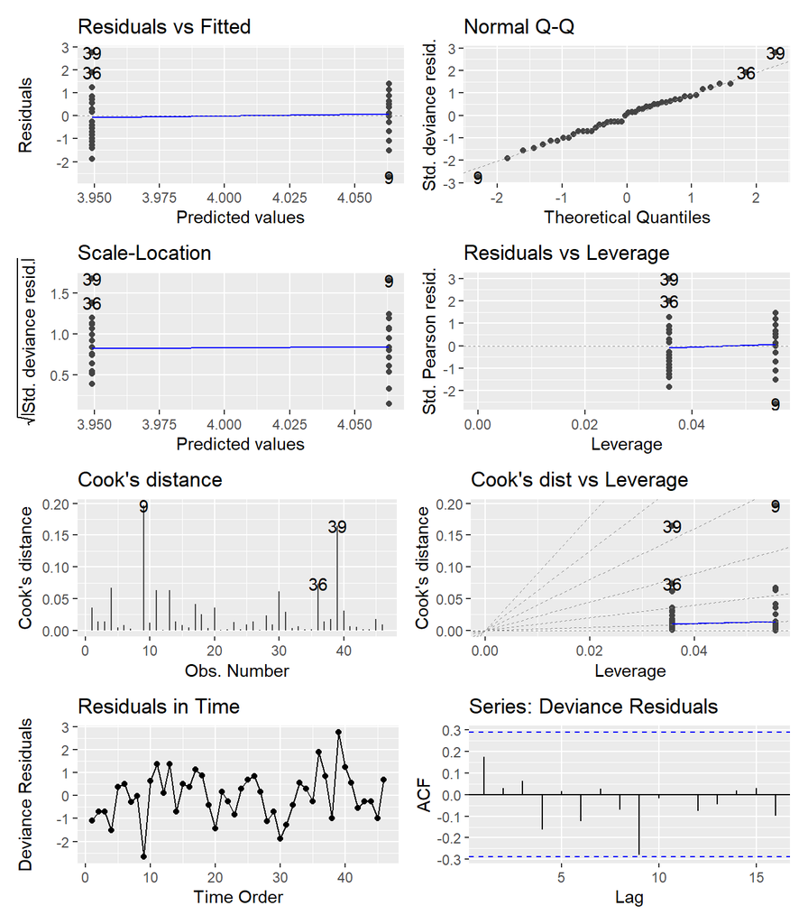

#### Change in counts of hurricanes

```
  SCUSUM Stat chpt Location       p-value
    0.2452840    18.0000000     0.2161666
```

In regime one, the mean number of hurricanes is 45.9444444 (CI: 42.917388, 49.1850057) and in regime two, the mean number of hurricanes is 41.5714286 (CI: 39.2505125, 44.0295824); a change of -4.3730159.

**Model Assessment**

The ratio of the residual deviance is 0.8838189.

The $p$-value for the Ljung-Box test on the deviance residuals 0.5093981.

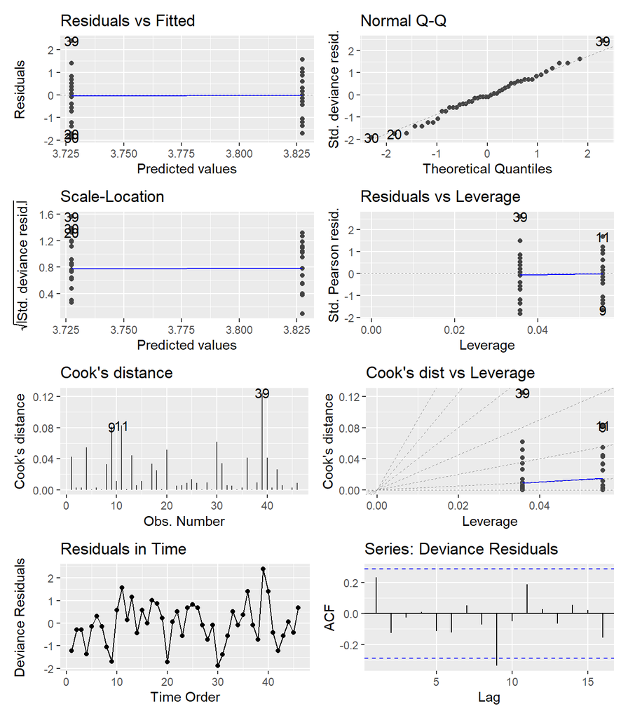

#### Change in counts of major storms

```
  SCUSUM Stat chpt Location       p-value
   0.39031559   11.00000000    0.08377019
```

In regime one, the mean number of storms is 19.8181818 (CI: 17.3545, 22.6316131) and in regime two, the mean number of storms is 24.6 (CI: 23.0104813, 26.2993195); a change of 4.7818182.

**Model Assessment**

The ratio of the residual deviance is 0.8673431.

The $p$-value for the Ljung-Box test on the deviance residuals 0.4067757.

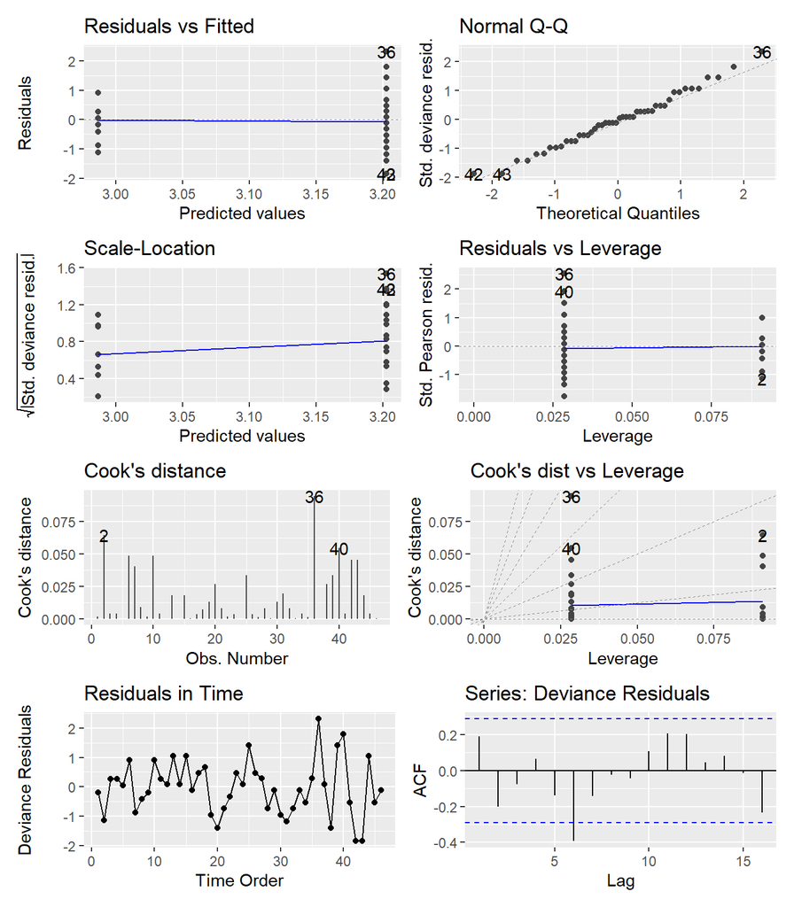

#### Change in counts of intense storms

```
  SCUSUM Stat chpt Location       p-value
 1.846357e+00  9.000000e+00  2.918197e-05
```

In regime one, the mean number of storms is 9.6666667 (CI: 7.8345976, 11.927153) and in regime two, the mean number of storms is 17.9189189 (CI: 16.6055502, 19.3361648); a change of 8.2522523.

**Model Assessment**

The ratio of the residual deviance is 1.0819347.

The $p$-value for the Ljung-Box test on the deviance residuals 0.312317.

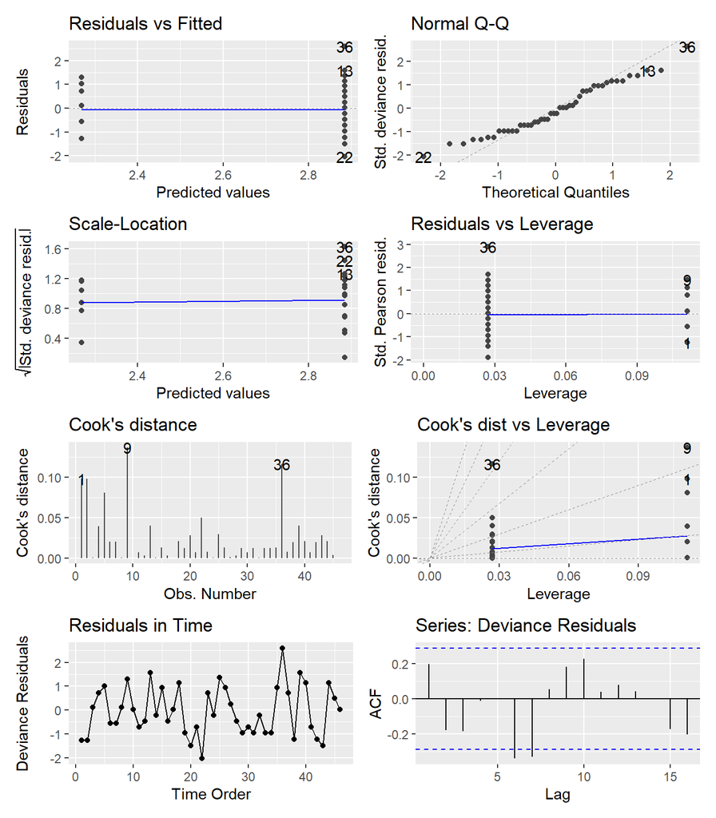

#### Proportion of major storms

A change in the proportion of major storms?

```
  SCUSUM Stat chpt Location       p-value
 1.179611e+00  2.100000e+01  9.802634e-04
```

In regime one, the proportion of major storms is 0.3912678 (CI: 0.3639274, 0.4193083) and in regime two, the proportion of major storms is 0.4682964 (CI: 0.4413833, 0.4953953); a change of 0.0770286.

**Model Assessment**

The ratio of the residual deviance is 1.0082193.

The $p$-value for the Ljung-Box test on the deviance residuals 0.3909745.

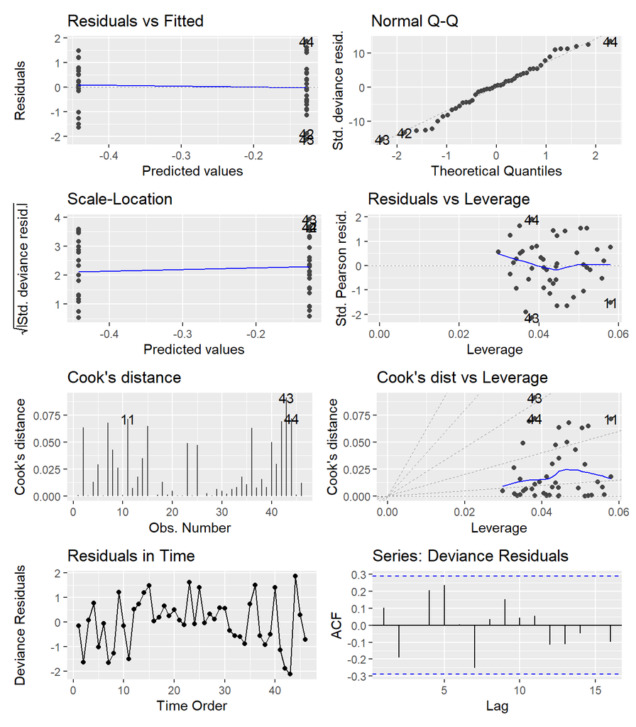

#### Proportion of intense storms

A change in the proportion of intense storms?

```
  SCUSUM Stat chpt Location       p-value
 3.348026e+00  2.200000e+01  1.310884e-08
```

In regime one, the proportion of intense storms is 0.2481869 (CI: 0.2249397, 0.2729905) and in regime two, the proportion of intense storms is 0.3510723 (CI: 0.3251817, 0.37787); a change of 0.1028853.

**Model Assessment**

The ratio of the residual deviance is 1.5412963.

The $p$-value for the Ljung-Box test on the deviance residuals 0.0627304.

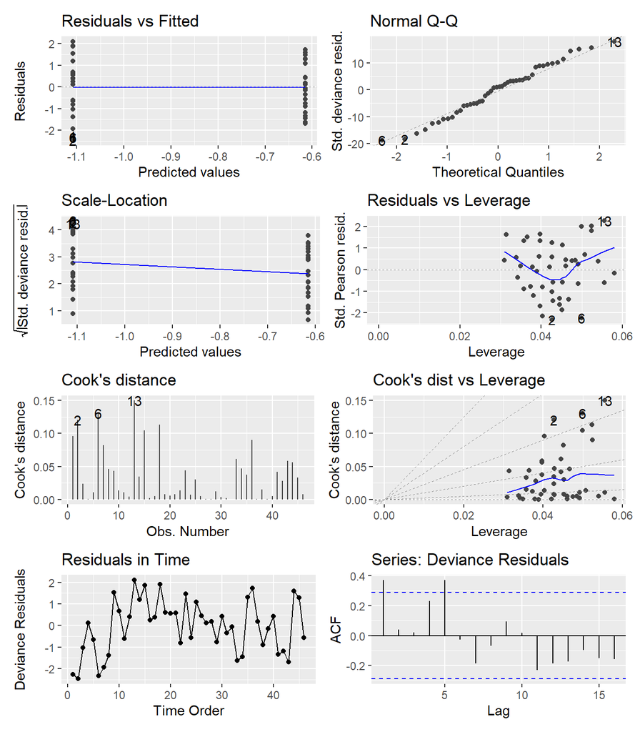

### Regression Methods

#### Poisson Regression on non-Shorties

```
Call:  glm(formula = Total_Storms ~ YearsSinceStart, family = poisson(link = "log"),
    data = storm_basin)

Coefficients:
    (Intercept)  YearsSinceStart
       4.035063        -0.001775

Degrees of Freedom: 45 Total (i.e. Null);  44 Residual
Null Deviance:      55.33
Residual Deviance: 53.94    AIC: 325.9
```

```
Single term deletions

Model:
Total_Storms ~ YearsSinceStart
                Df Deviance    AIC    LRT Pr(>Chi)
<none>               53.937 325.90
YearsSinceStart  1   55.325 325.29 1.3879   0.2388
```

Using this model, in 1980 we would predict 56.5465024 storms (CI: 52.3896579, 61.0331706) and in 2025 we predict 52.2056457 storms (CI: 48.291003, 56.4376234).

That is a change of -0.9436645 storms per decade.

**Model Assessment**

The ratio of the residual deviance is 1.2258465.

The $p$-value for the Ljung-Box test on the deviance residuals 0.3851486.

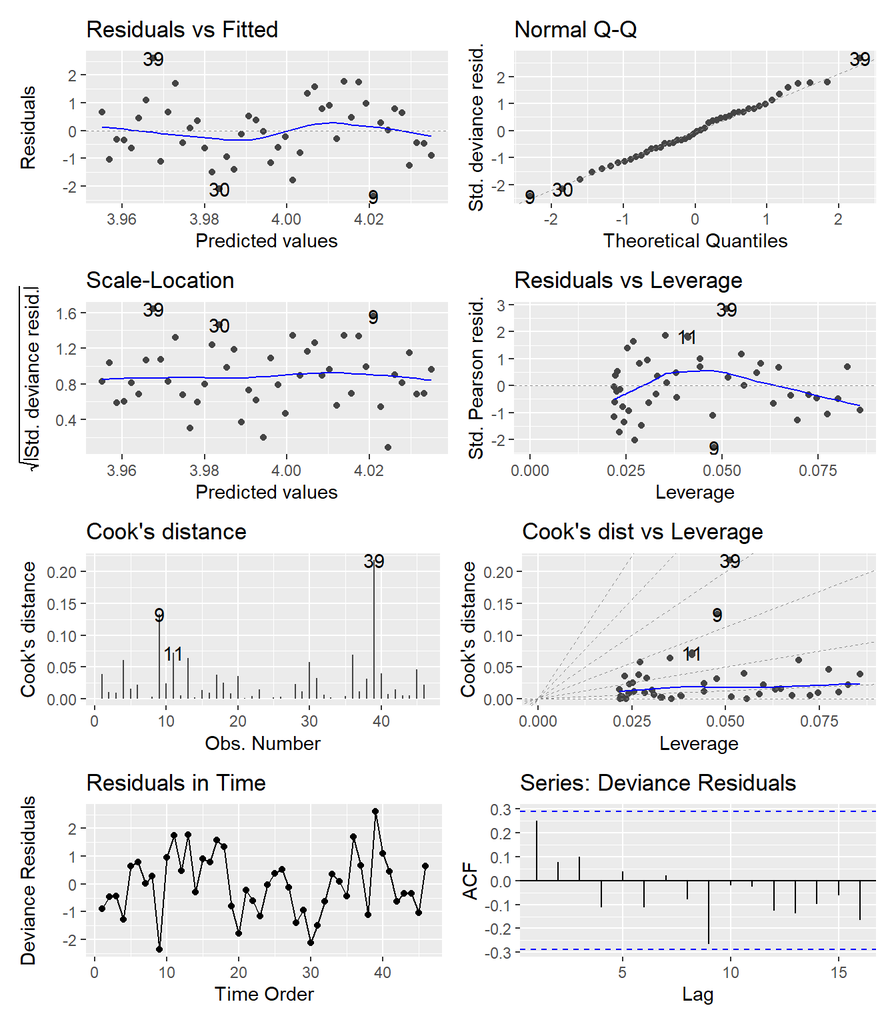

#### Poisson Regression on Hurricanes

```
Call:  glm(formula = Hurricanes ~ YearsSinceStart, family = poisson(link = "log"),
    data = storm_basin)

Coefficients:
    (Intercept)  YearsSinceStart
       3.807265        -0.001768

Degrees of Freedom: 45 Total (i.e. Null);  44 Residual
Null Deviance:      43.7
Residual Deviance: 42.6     AIC: 304.1
```

```
Single term deletions

Model:
Hurricanes ~ YearsSinceStart
                Df Deviance    AIC    LRT Pr(>Chi)
<none>               42.598 304.13
YearsSinceStart  1   43.696 303.23 1.0973   0.2949
```

Using this model, in 1980 we would predict 45.027127 hurricanes (CI: 41.3347146, 49.0493811) and in 2025 we predict 41.5827541 hurricanes (CI: 38.1050401, 45.3778669).

That is a change of -0.7487767 hurricanes per decade.

**Model Assessment**

The ratio of the residual deviance is 0.9681472.

The $p$-value for the Ljung-Box test on the deviance residuals 0.3731077.

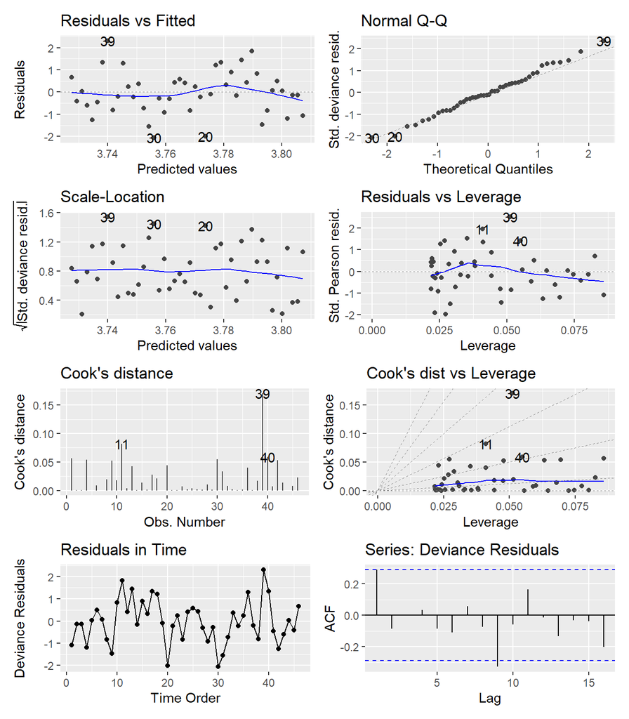

#### Poisson Regression on Major Storms

```
Call:  glm(formula = Major_Storms ~ YearsSinceStart, family = poisson(link = "log"),
    data = storm_basin)

Coefficients:
    (Intercept)  YearsSinceStart
       3.064932         0.003949

Degrees of Freedom: 45 Total (i.e. Null);  44 Residual
Null Deviance:      46.64
Residual Deviance: 43.68    AIC: 276.7
```

```
Single term deletions

Model:
Major_Storms ~ YearsSinceStart
                Df Deviance    AIC    LRT Pr(>Chi)
<none>               43.677 276.71
YearsSinceStart  1   46.639 277.67 2.9626  0.08521 .
---
Signif. codes:  0 '***' 0.001 '**' 0.01 '*' 0.05 '.' 0.1 ' ' 1
```

Using this model, in 1980 we would predict 21.4330118 major storms (CI: 19.0056719, 24.1703633) and in 2025 we predict 25.6006467 major storms (CI: 22.8240008, 28.7150845).

That is a change of 0.9060076 major storms per decade.

**Model Assessment**

The ratio of the residual deviance is 0.9926543.

The $p$-value for the Ljung-Box test on the deviance residuals 0.3649486.

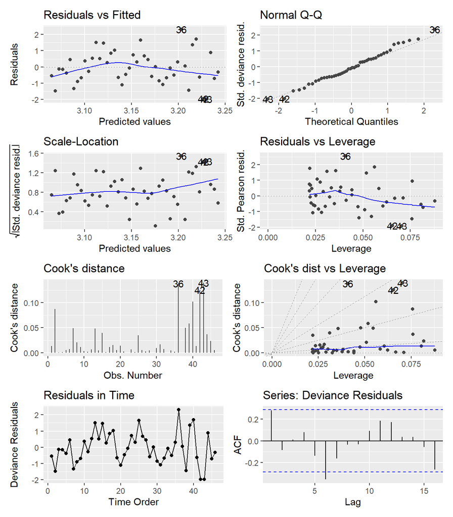

#### Poisson Regression on Intense Storms

```
Call:  glm(formula = Intense_Storms ~ YearsSinceStart, family = poisson(link = "log"),
    data = storm_basin)

Coefficients:
    (Intercept)  YearsSinceStart
        2.51938          0.01157

Degrees of Freedom: 45 Total (i.e. Null);  44 Residual
Null Deviance:      81.85
Residual Deviance: 64.29    AIC: 279
```

```
Single term deletions

Model:
Intense_Storms ~ YearsSinceStart
                Df Deviance    AIC    LRT  Pr(>Chi)
<none>               64.289 279.05
YearsSinceStart  1   81.855 294.61 17.565 2.776e-05 ***
---
Signif. codes:  0 '***' 0.001 '**' 0.01 '*' 0.05 '.' 0.1 ' ' 1
```

Using this model, in 1980 we would predict 12.420915 intense storms (CI: 10.678129, 14.4481426) and in 2025 we predict 20.9042177 intense storms (CI: 18.3157967, 23.8584389).

That is a change of 1.8441962 intense storms per decade.

**Model Assessment**

The ratio of the residual deviance is 1.4611231.

The $p$-value for the Ljung-Box test on the deviance residuals 0.1048656.

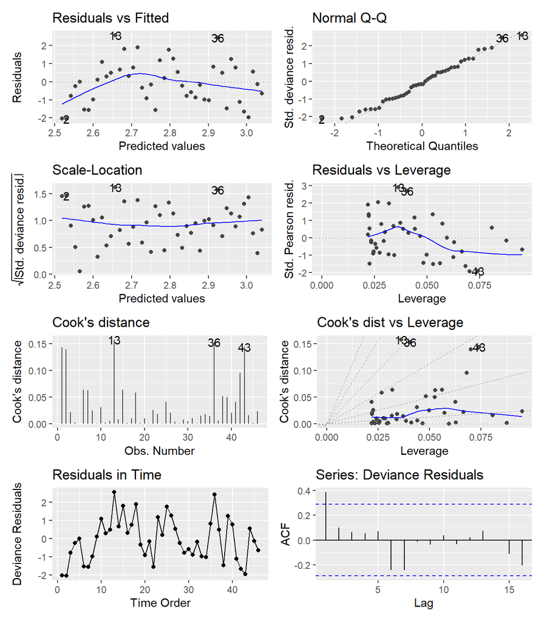

#### Logistic Regression on Proportions of Major

```
Call:  glm(formula = cbind(Major_Storms, Non_Major) ~ YearsSinceStart,
    family = binomial, data = prop_data)

Coefficients:
    (Intercept)  YearsSinceStart
       -0.50040          0.01009

Degrees of Freedom: 45 Total (i.e. Null);  44 Residual
Null Deviance:      59.47
Residual Deviance: 48.51    AIC: 255
```

```
Single term deletions

Model:
cbind(Major_Storms, Non_Major) ~ YearsSinceStart
                Df Deviance    AIC    LRT  Pr(>Chi)
<none>               48.507 255.05
YearsSinceStart  1   59.471 264.01 10.965 0.0009287 ***
---
Signif. codes:  0 '***' 0.001 '**' 0.01 '*' 0.05 '.' 0.1 ' ' 1
```

Using this model, in 1980 the probability of a major storm in was 0.3774476 (CI: 0.3415788, 0.4147105) and in 2025 the probability of a major storm was 0.4884082 (CI: 0.4494239, 0.5275341).

That is a change of 2.412187 percent per decade.

**Model Assessment**

The ratio of the residual deviance is 1.1024224.

The $p$-value for the Ljung-Box test on the deviance residuals 0.4107534.

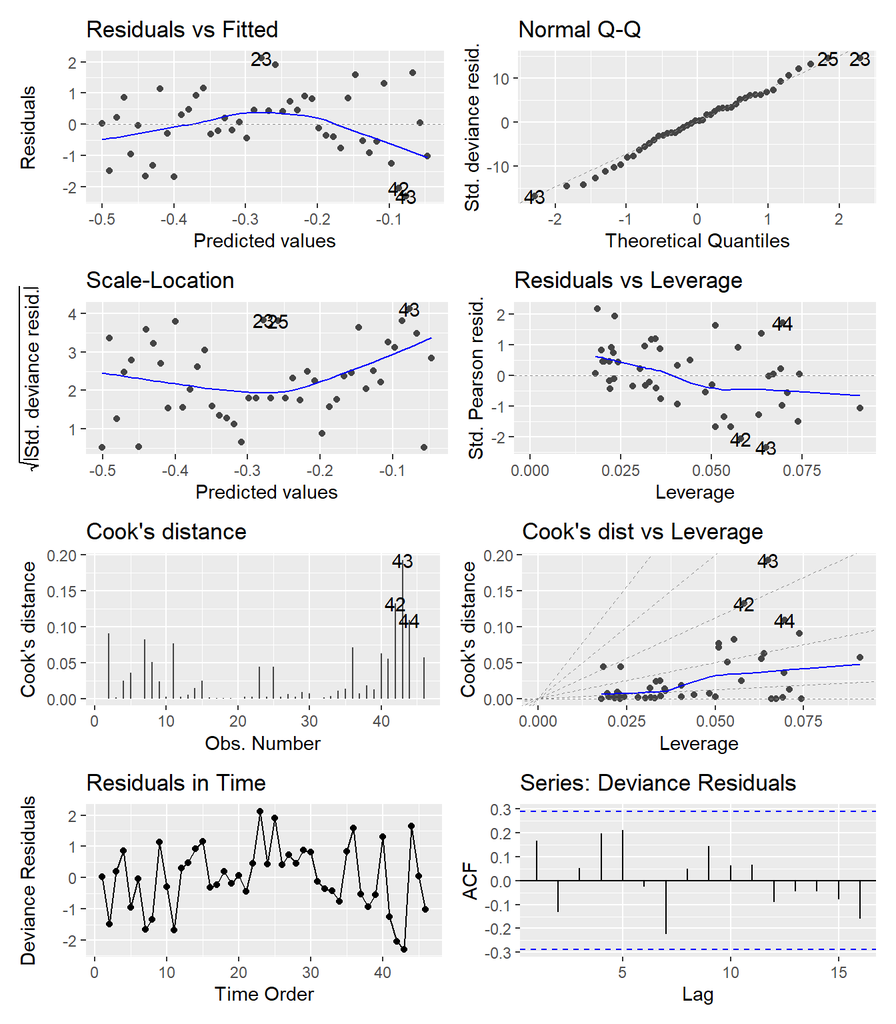

#### Logistic Regression on Proportions of Intense

```
Call:  glm(formula = cbind(Intense_Storms, Non_Intense) ~ YearsSinceStart,
    family = binomial, data = prop_data)

Coefficients:
    (Intercept)  YearsSinceStart
       -1.28446          0.01913

Degrees of Freedom: 45 Total (i.e. Null);  44 Residual
Null Deviance:      99.45
Residual Deviance: 65.99    AIC: 263.9
```

```
Single term deletions

Model:
cbind(Intense_Storms, Non_Intense) ~ YearsSinceStart
                Df Deviance    AIC   LRT  Pr(>Chi)
<none>               65.993 263.94
YearsSinceStart  1   99.453 295.39 33.46 7.275e-09 ***
---
Signif. codes:  0 '***' 0.001 '**' 0.01 '*' 0.05 '.' 0.1 ' ' 1
```

**Model Assessment**

The ratio of the residual deviance is 1.4998321.

The $p$-value for the Ljung-Box test on the deviance residuals 0.2704871.

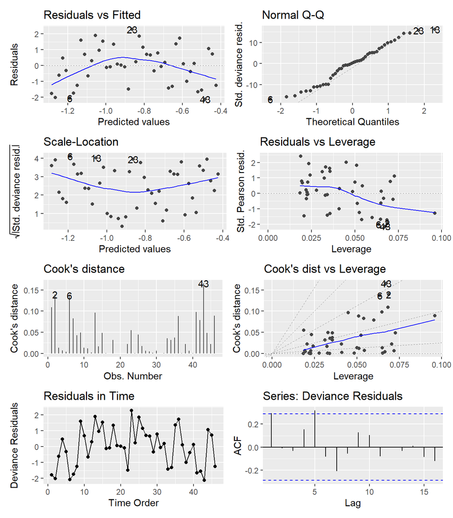

## HURSAT Quick Results

### Summary Statistics and Data

| Total Storms (Avg) | Total Storms (stddev) | Hurricanes (Avg) | Hurricanes (stddev) | Major Storms (Avg) | Major Storms (stddev) | Prop Major Storms | Intense Storms (Avg) | Intense Storms (stddev) | Prop Intense Storms |
| --- | --- | --- | --- | --- | --- | --- | --- | --- | --- |
| 45.52273 | 7.206227 | 35.25 | 5.698327 | 24.5 | 5.367863 | 0.5381927 | 16.15909 | 4.714861 | 0.3549675 |

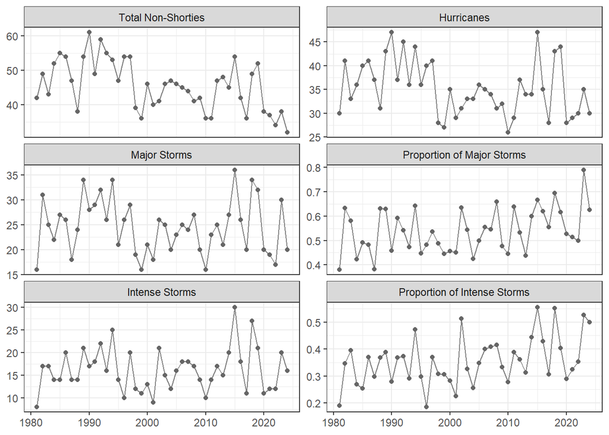

### Testing Results

**Changepoint Methods**

Here, we report the estimate mean for each segment or regime regardless of whether the test found a significant shift.

| Response | Chpt.Location | p.value | Regime1 | Regime2 | Change | Perc_Change |
| --- | --- | --- | --- | --- | --- | --- |
| Cyclone Freq | 1998 | 0.00033 | 50.94118 | 42.11111 | -8.83007 | -17.33385 |
| Hurricanes | 1998 | 0.05369 | 38.70588 | 33.07407 | -5.63181 | -14.55026 |
| Major Freq | 1998 | 0.47186 | 26.35294 | 23.33333 | -3.01961 | -11.45833 |
| Prop Major | 2014 | 0.00420 | 51.55239 | 61.48796 | 9.93557 | 19.27277 |
| Intense Freq | 2014 | 0.51155 | 15.54545 | 18.00000 | 2.45455 | 15.78947 |
| Prop Freq | 2002 | 0.00081 | 31.74294 | 39.44672 | 7.70378 | 24.26927 |

**Generalized Linear Model Approaches**

Note:

- we report the Likelihood Ratio Test for the generalized linear models, this is better to use than the default $Z$-test provided in the `summary()` output.
- the Change per decade is found by comparing the predicted value at the start time (1981) and end time (2024) and scaling by the number of years $\times 10$.

| Response | Coefficent | p.value | Start | End | Change per Decade |
| --- | --- | --- | --- | --- | --- |
| Cyclone Freq | -0.00626 | 0.00038 | 51.91416 | 39.66709 | -2.78343 |
| Hurricanes | -0.00366 | 0.06712 | 38.09643 | 32.54581 | -1.26150 |
| Major Freq | -0.00147 | 0.54078 | 25.28071 | 23.73516 | -0.35126 |
| Prop Major | 0.01066 | 0.00293 | 48.38443 | 59.71655 | 2.57548 |
| Intense Freq | 0.00217 | 0.46299 | 15.41739 | 16.92365 | 0.34233 |
| Prop Freq | 0.01341 | 0.00032 | 29.39736 | 42.56840 | 2.99342 |

## HURSAT Full Analysis

### Changepoint Methods

#### Change in Non-Shorty Counts

```
  SCUSUM Stat chpt Location       p-value
 1.384965e+00  1.700000e+01  3.283888e-04
```

The dates suggest the changepoint would occur from 1997 to 1998 with $p$-value 3.2838881^{-4}.

In regime one, the mean number of storms is 50.9411765 (CI: 47.6588362, 54.4495767) and in regime two, the mean number of storms is 42.1111111 (CI: 39.7331124, 44.6314314); a change of -8.8300654.

**Model Assessment**

The ratio of the residual deviance is 0.7509062.

The $p$-value for the Ljung-Box test on the deviance residuals 0.6043594.

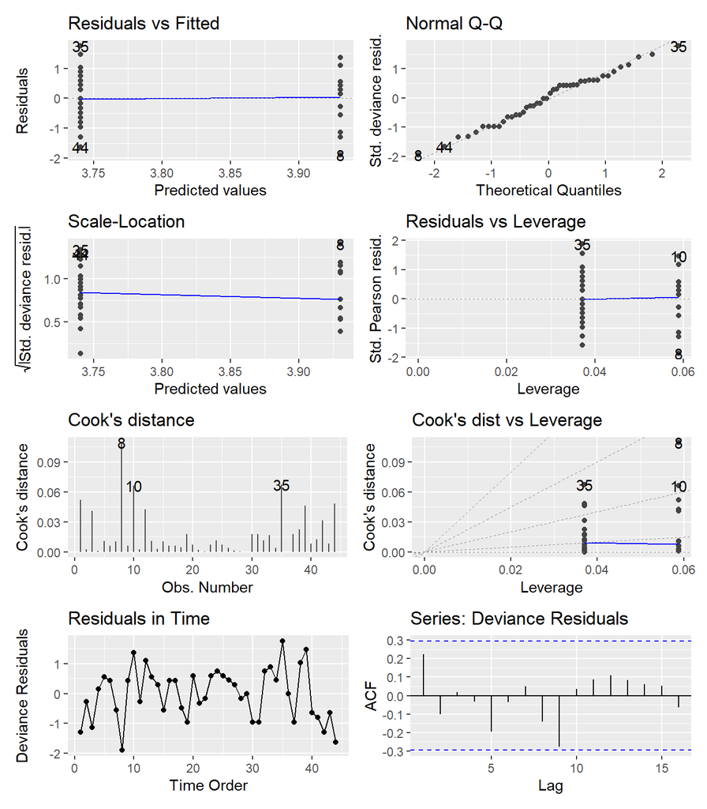

#### Change in counts of hurricanes

```
  SCUSUM Stat chpt Location       p-value
   0.46312680   17.00000000    0.05369102
```

The dates suggest the changepoint would occur from 1997 to 1998 with $p$-value 0.053691.

In regime one, the mean number of hurricanes is 38.7058824 (CI: 35.8585787, 41.7792725) and in regime two, the mean number of hurricanes is 33.0740741 (CI: 30.9743925, 35.3160881); a change of -5.6318083.

**Model Assessment**

The ratio of the residual deviance is 0.7095169.

The $p$-value for the Ljung-Box test on the deviance residuals 0.5767601.

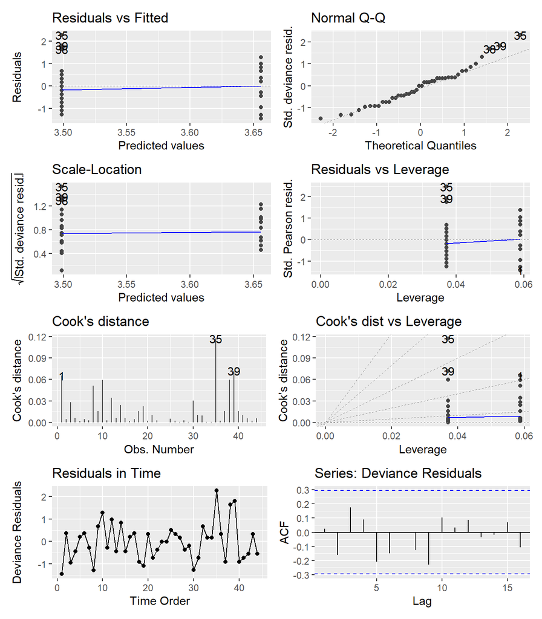

#### Change in counts of major storms

```
  SCUSUM Stat chpt Location       p-value
    0.1422774    17.0000000     0.4718614
```

The dates suggest the changepoint would occur from 1997 to 1998 with $p$-value 0.4718614.

In regime one, the mean number of storms is 26.3529412 (CI: 24.0222046, 28.9098158) and in regime two, the mean number of storms is 23.3333333 (CI: 21.5805983, 25.2284221); a change of -3.0196078.

**Model Assessment**

The ratio of the residual deviance is 1.1074844.

The $p$-value for the Ljung-Box test on the deviance residuals 0.6255206.

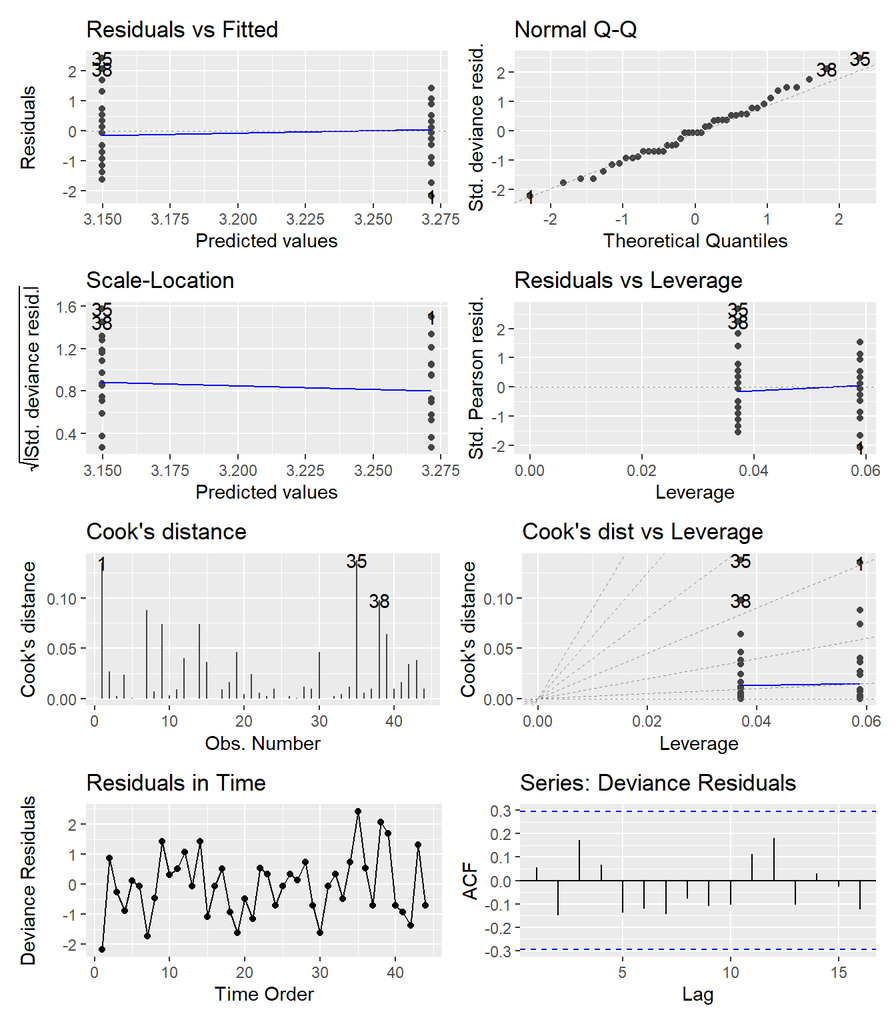

#### Change in counts of intense storms

```
  SCUSUM Stat chpt Location       p-value
    0.1328544    33.0000000     0.5115516
```

The dates suggest the changepoint would occur from 2013 to 2014 with $p$-value 0.5115516.

In regime one, the mean number of storms is 15.5454545 (CI: 14.2567742, 16.9506197) and in regime two, the mean number of storms is 18 (CI: 15.6595461, 20.6902548); a change of 2.4545455.

**Model Assessment**

The ratio of the residual deviance is 1.2957642.

The $p$-value for the Ljung-Box test on the deviance residuals 0.3892762.

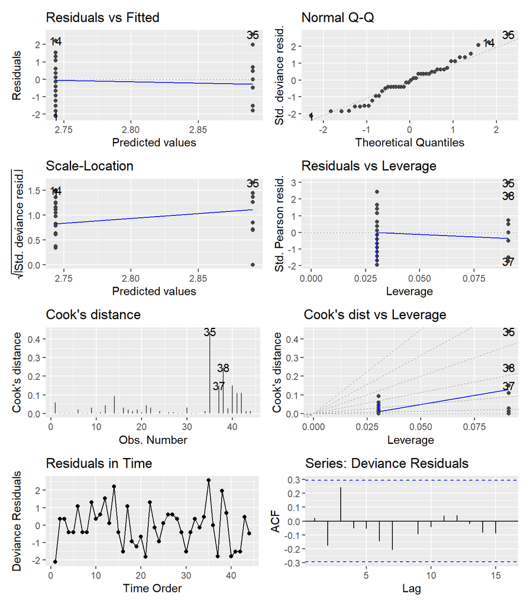

#### Proportion of major storms

A change in the proportion of major storms?

```
  SCUSUM Stat chpt Location       p-value
  0.910985591  33.000000000   0.004199175
```

The change in proportions occurs 2013 to 2014 with $p$-value 0.0041992.

In regime one, the proportion of major storms is 0.5155239 (CI: 0.4905938, 0.540377) and in regime two, the proportion of major storms is 0.6148796 (CI: 0.5694141, 0.6584243); a change of 0.0993557.

**Model Assessment**

The ratio of the residual deviance is 1.2192269.

The $p$-value for the Ljung-Box test on the deviance residuals 0.0747914.

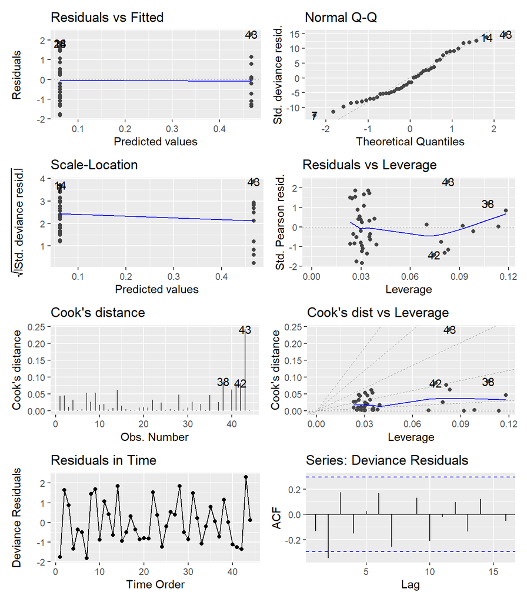

#### Proportion of intense storms

A change in the proportion of intense storms?

```
  SCUSUM Stat chpt Location       p-value
 1.214267e+00  2.100000e+01  8.142951e-04
```

The change in proportions occurs 2001 to 2002 with $p$-value 8.1429511^{-4}.

In regime one, the proportion of intense storms is 0.3174294 (CI: 0.2896666, 0.3465549) and in regime two, the proportion of intense storms is 0.3944672 (CI: 0.3642556, 0.4255075); a change of 0.0770378.

**Model Assessment**

The ratio of the residual deviance is 1.3236011.

The $p$-value for the Ljung-Box test on the deviance residuals 0.1774139.

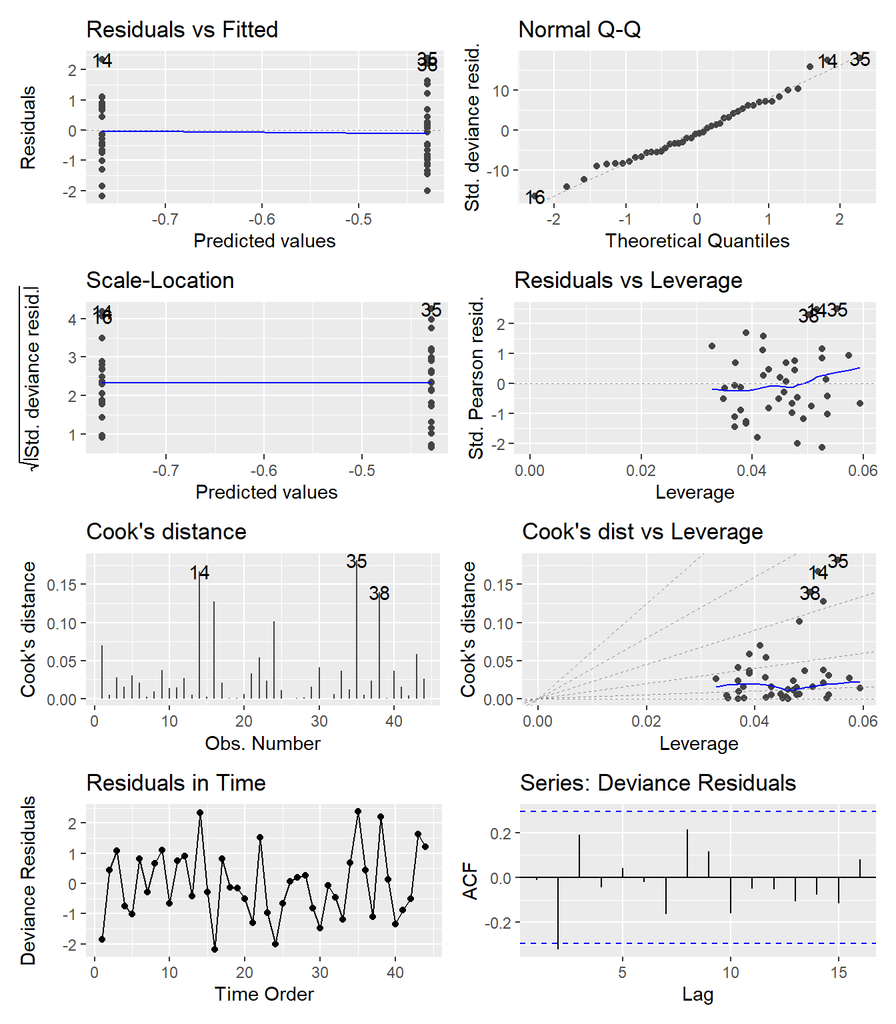

### Regression Methods

#### Poisson Regression on non-Shorties

```
Call:  glm(formula = Total_Storms ~ YearsSinceStart, family = poisson(link = "log"),
    data = storm_basin)

Coefficients:
    (Intercept)  YearsSinceStart
       3.949592        -0.006257

Degrees of Freedom: 43 Total (i.e. Null);  42 Residual
Null Deviance:      49.17
Residual Deviance: 36.55    AIC: 289
```

```
Single term deletions

Model:
Total_Storms ~ YearsSinceStart
                Df Deviance    AIC    LRT  Pr(>Chi)
<none>               36.551 289.04
YearsSinceStart  1   49.174 299.66 12.623 0.0003811 ***
---
Signif. codes:  0 '***' 0.001 '**' 0.01 '*' 0.05 '.' 0.1 ' ' 1
```

Using this model, in 1981 we would predict 51.9141637 storms (CI: 47.7670191, 56.4213644) and in 2024 we predict 39.6670912 storms (CI: 36.2800377, 43.3703554).

That is a change of -2.7834256 storms per decade.

**Model Assessment**

The ratio of the residual deviance is 0.8702646.

The $p$-value for the Ljung-Box test on the deviance residuals 0.4136642.

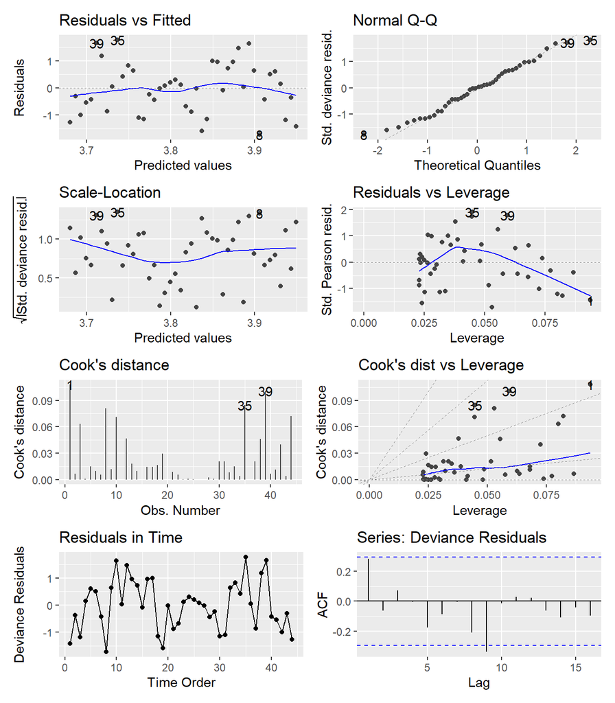

#### Poisson Regression on Hurricanes

```
Call:  glm(formula = Hurricanes ~ YearsSinceStart, family = poisson(link = "log"),
    data = storm_basin)

Coefficients:
    (Intercept)  YearsSinceStart
       3.640120        -0.003662

Degrees of Freedom: 43 Total (i.e. Null);  42 Residual
Null Deviance:      39.08
Residual Deviance: 35.73    AIC: 277
```

```
Single term deletions

Model:
Hurricanes ~ YearsSinceStart
                Df Deviance    AIC   LRT Pr(>Chi)
<none>               35.732 277.01
YearsSinceStart  1   39.084 278.36 3.352  0.06712 .
---
Signif. codes:  0 '***' 0.001 '**' 0.01 '*' 0.05 '.' 0.1 ' ' 1
```

Using this model, in 1981 we would predict 38.0964256 hurricanes (CI: 34.6118686, 41.9317911) and in 2024 we predict 32.5458056 hurricanes (CI: 29.4512961, 35.9654616).

That is a change of -1.2615046 hurricanes per decade.

**Model Assessment**

The ratio of the residual deviance is 0.8507523.

The $p$-value for the Ljung-Box test on the deviance residuals 0.3956337.

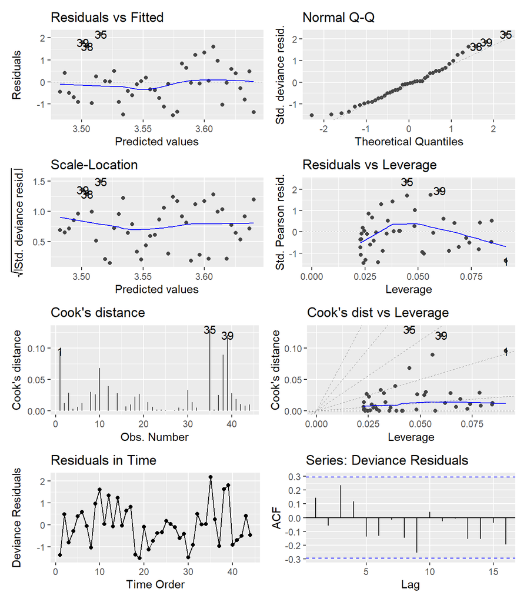

#### Poisson Regression on Major Storms

```
Call:  glm(formula = Major_Storms ~ YearsSinceStart, family = poisson(link = "log"),
    data = storm_basin)

Coefficients:
    (Intercept)  YearsSinceStart
       3.230042        -0.001467

Degrees of Freedom: 43 Total (i.e. Null);  42 Residual
Null Deviance:      50.36
Residual Deviance: 49.99    AIC: 274.9
```

```
Single term deletions

Model:
Major_Storms ~ YearsSinceStart
                Df Deviance    AIC     LRT Pr(>Chi)
<none>               49.989 274.87
YearsSinceStart  1   50.363 273.24 0.37409   0.5408
```

Using this model, in 1981 we would predict 25.2807105 major storms (CI: 22.5019775, 28.4025848) and in 2024 we predict 23.7351605 major storms (CI: 21.0858839, 26.717298).

That is a change of -0.3512614 major storms per decade.

**Model Assessment**

The ratio of the residual deviance is 1.190217.

The $p$-value for the Ljung-Box test on the deviance residuals 0.587468.

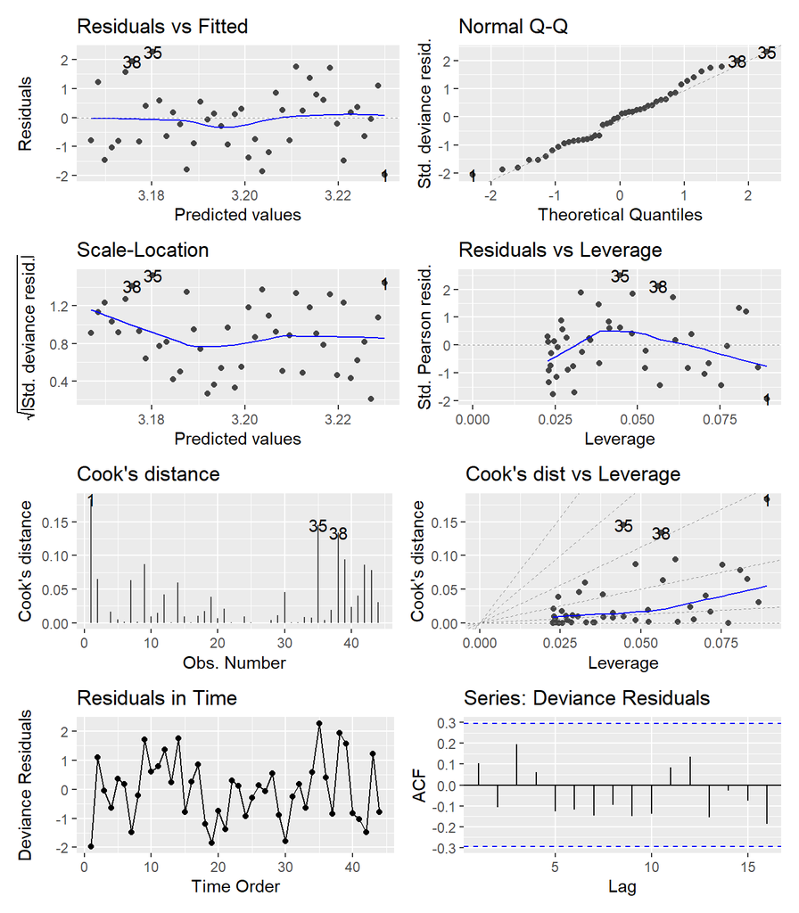

#### Poisson Regression on Intense Storms

```
Call:  glm(formula = Intense_Storms ~ YearsSinceStart, family = poisson(link = "log"),
    data = storm_basin)

Coefficients:
    (Intercept)  YearsSinceStart
       2.735496         0.002168

Degrees of Freedom: 43 Total (i.e. Null);  42 Residual
Null Deviance:      57.43
Residual Deviance: 56.89    AIC: 262.9
```

```
Single term deletions

Model:
Intense_Storms ~ YearsSinceStart
                Df Deviance    AIC     LRT Pr(>Chi)
<none>               56.886 262.88
YearsSinceStart  1   57.425 261.42 0.53866    0.463
```

Using this model, in 1981 we would predict 15.417386 intense storms (CI: 13.3189097, 17.84649) and in 2024 we predict 16.9236497 intense storms (CI: 14.6711935, 19.5219236).

That is a change of 0.3423327 intense storms per decade.

**Model Assessment**

The ratio of the residual deviance is 1.3544375.

The $p$-value for the Ljung-Box test on the deviance residuals 0.4209645.

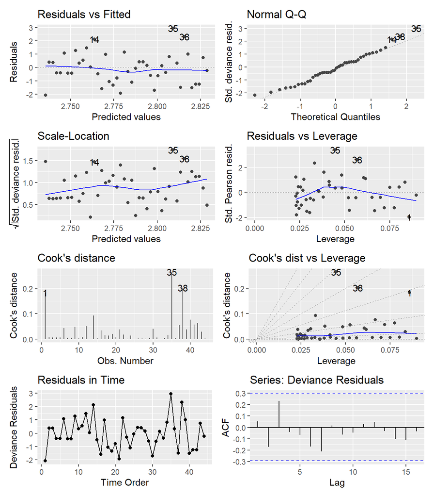

#### Logistic Regression on Proportions of Major

```
Call:  glm(formula = cbind(Major_Storms, Non_Major) ~ YearsSinceStart,
    family = binomial, data = prop_data)

Coefficients:
    (Intercept)  YearsSinceStart
       -0.06465          0.01066

Degrees of Freedom: 43 Total (i.e. Null);  42 Residual
Null Deviance:      65.34
Residual Deviance: 56.49    AIC: 246.5
```

```
Single term deletions

Model:
cbind(Major_Storms, Non_Major) ~ YearsSinceStart
                Df Deviance    AIC    LRT Pr(>Chi)
<none>               56.494 246.51
YearsSinceStart  1   65.341 253.36 8.8475 0.002935 **
---
Signif. codes:  0 '***' 0.001 '**' 0.01 '*' 0.05 '.' 0.1 ' ' 1
```

Using this model, in 1981 the probability of a major storm in was 0.4838443 (CI: 0.4420547, 0.525861) and in 2024 the probability of a major storm was 0.5971655 (CI: 0.5527047, 0.6400848).

That is a change of 2.5754823 percent per decade.

**Model Assessment**

The ratio of the residual deviance is 1.3450916.

The $p$-value for the Ljung-Box test on the deviance residuals 0.1645886.

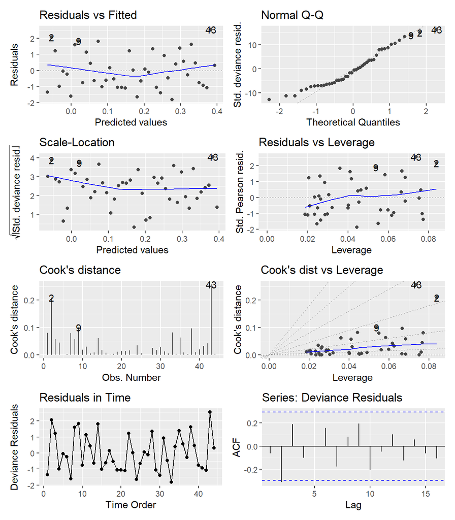

#### Logistic Regression on Proportions of Intense

```
Call:  glm(formula = cbind(Intense_Storms, Non_Intense) ~ YearsSinceStart,
    family = binomial, data = prop_data)

Coefficients:
    (Intercept)  YearsSinceStart
       -0.87616          0.01341

Degrees of Freedom: 43 Total (i.e. Null);  42 Residual
Null Deviance:      68.57
Residual Deviance: 55.65    AIC: 241.9
```

```
Single term deletions

Model:
cbind(Intense_Storms, Non_Intense) ~ YearsSinceStart
                Df Deviance    AIC    LRT  Pr(>Chi)
<none>               55.646 241.95
YearsSinceStart  1   68.571 252.87 12.925 0.0003243 ***
---
Signif. codes:  0 '***' 0.001 '**' 0.01 '*' 0.05 '.' 0.1 ' ' 1
```

That is a change of 2.9934177 percent per decade.

**Model Assessment**

The ratio of the residual deviance is 1.3249073.

The $p$-value for the Ljung-Box test on the deviance residuals 0.1326956.

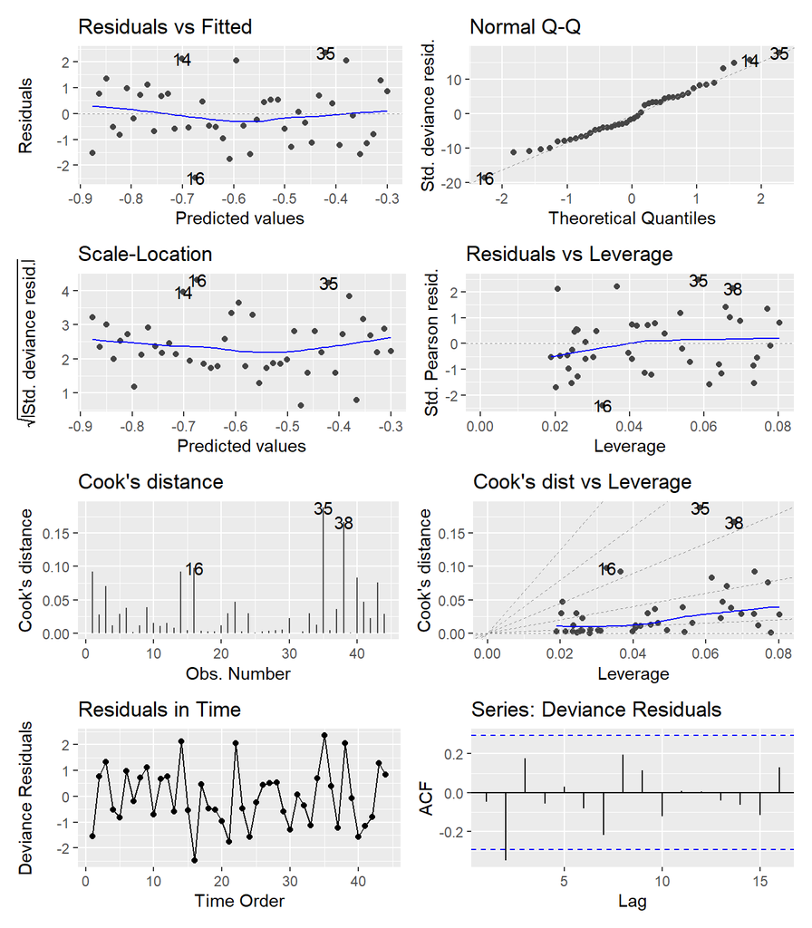

# North Atlantic

## IBTrACS Quick Results

### Summary Statistics and Data

| Total Storms (Avg) | Total Storms (stddev) | Hurricanes (Avg) | Hurricanes (stddev) | Major Storms (Avg) | Major Storms (stddev) | Prop Major Storms | Intense Storms (Avg) | Intense Storms (stddev) | Prop Intense Storms |
| --- | --- | --- | --- | --- | --- | --- | --- | --- | --- |
| 8.565217 | 3.775077 | 6.326087 | 2.898692 | 2.891304 | 1.804048 | 0.3375635 | 1.826087 | 1.510031 | 0.213198 |

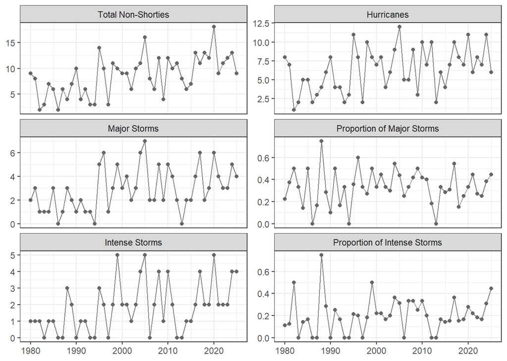

### Testing Results

**Changepoint Methods**

Here, we report the estimate mean for each segment or regime regardless of whether the test found a significant shift.

| Response | Chpt.Location | p.value | Regime1 | Regime2 | Change | Perc_Change |
| --- | --- | --- | --- | --- | --- | --- |
| Cyclone Freq | 1996 | 0.00000 | 5.33333 | 10.12903 | 4.79570 | 89.91935 |
| Hurricanes | 1996 | 0.00195 | 4.26667 | 7.32258 | 3.05591 | 71.62298 |
| Major Freq | 1996 | 0.00338 | 1.46667 | 3.58065 | 2.11398 | 144.13490 |
| Prop Major | 1996 | 0.92124 | 27.50000 | 35.35032 | 7.85032 | 28.54661 |
| Intense Freq | 1999 | 0.00182 | 0.94444 | 2.39286 | 1.44841 | 153.36134 |
| Prop Freq | 2000 | 0.62795 | 16.10169 | 23.55072 | 7.44903 | 46.26240 |

**Generalized Linear Model Approaches**

Note:

- we report the Likelihood Ratio Test for the generalized linear models, this is better to use than the default $Z$-test provided in the `summary()` output.
- the Change per decade is found by comparing the predicted value at the start time (1980) and end time (2025) and scaling by the number of years $\times 10$.

| Response | Coefficent | p.value | Start | End | Change per Decade |
| --- | --- | --- | --- | --- | --- |
| Cyclone Freq | 0.01899 | 0.00000 | 5.41376 | 12.72206 | 1.58876 |
| Hurricanes | 0.01389 | 0.00175 | 4.55061 | 8.50133 | 0.85885 |
| Major Freq | 0.01952 | 0.00309 | 1.80254 | 4.33847 | 0.55129 |
| Prop Major | 0.00083 | 0.92058 | 33.27925 | 34.11269 | 0.18118 |
| Intense Freq | 0.02730 | 0.00112 | 0.92585 | 3.16350 | 0.48645 |
| Prop Freq | 0.01090 | 0.26146 | 16.90284 | 24.93329 | 1.74575 |

## IBTrACS Full Analysis

### Changepoint Methods

#### Change in Non-Shorty Counts

```
  SCUSUM Stat chpt Location       p-value
 2.554864e+00  1.500000e+01  7.518766e-07
```

In regime one, the mean number of storms is 5.3333333 (CI: 4.2838124, 6.6399837) and in regime two, the mean number of storms is 10.1290323 (CI: 9.0684072, 11.3137062); a change of 4.7956989.

**Model Assessment**

The ratio of the residual deviance is 1.1564567.

The $p$-value for the Ljung-Box test on the deviance residuals 0.9017638.

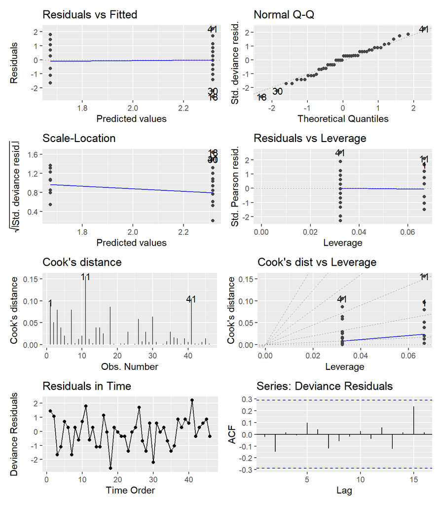

#### Change in counts of hurricanes

```
  SCUSUM Stat chpt Location       p-value
  1.052307245  15.000000000   0.001945243
```

In regime one, the mean number of hurricanes is 4.2666667 (CI: 3.3395502, 5.4511666) and in regime two, the mean number of hurricanes is 7.3225806 (CI: 6.4293486, 8.3399098); a change of 3.055914.

**Model Assessment**

The ratio of the residual deviance is 1.1120169.

The $p$-value for the Ljung-Box test on the deviance residuals 0.3853452.

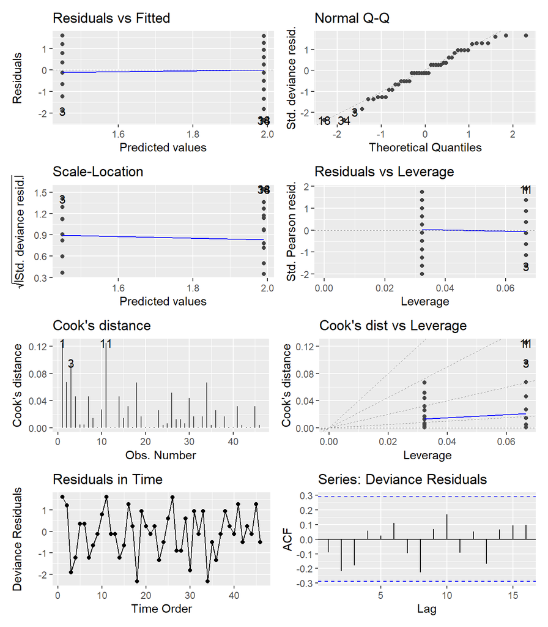

#### Change in counts of major storms

```
  SCUSUM Stat chpt Location       p-value
  0.950887971  15.000000000   0.003375499
```

In regime one, the mean number of storms is 1.4666667 (CI: 0.9657202, 2.2274683) and in regime two, the mean number of storms is 3.5806452 (CI: 2.9728112, 4.3127595); a change of 2.1139785.

**Model Assessment**

The ratio of the residual deviance is 0.8857319.

The $p$-value for the Ljung-Box test on the deviance residuals 0.2586055.

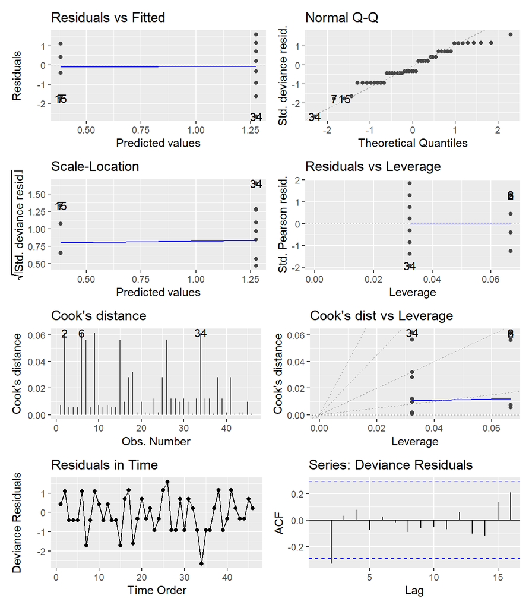

#### Change in counts of intense storms

```
  SCUSUM Stat chpt Location       p-value
  1.064317220  18.000000000   0.001822932
```

In regime one, the mean number of storms is 0.9444444 (CI: 0.5871197, 1.5192392) and in regime two, the mean number of storms is 2.3928571 (CI: 1.8833197, 3.0402514); a change of 1.4484127.

**Model Assessment**

The ratio of the residual deviance is 1.178519.

The $p$-value for the Ljung-Box test on the deviance residuals 0.0603571.

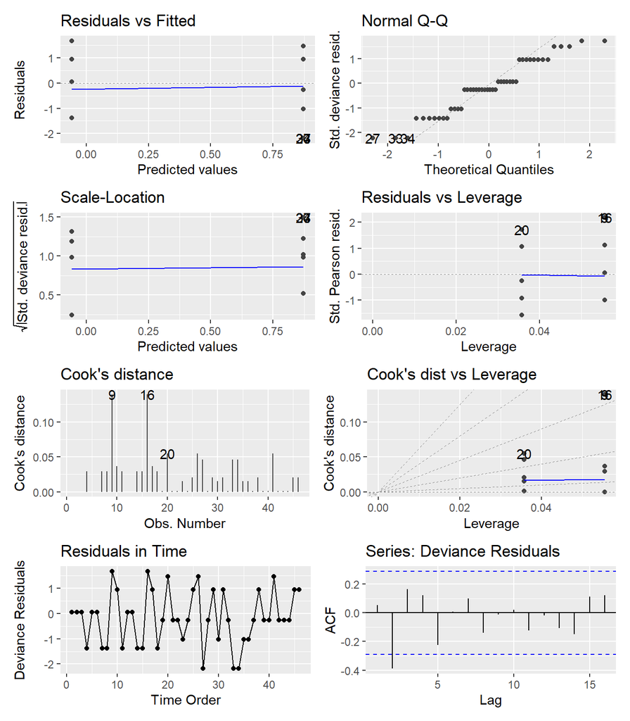